# Acquisition of Gesture

Dan Yurovsky

2017-06-22

Let’s try out some basic descriptives. What do these things look like? Let’s arrange them in order of difficulty(on the bases of highest proportion of non-producers).

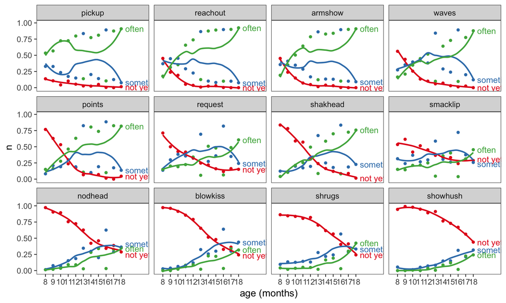

```r
eng_data <- get_instrument_data(instrument_language = "English",
                                instrument_form = "WG",
                                administrations = TRUE,
                                iteminfo = TRUE)

gesture_data <- eng_data %>%
  filter(str_detect(type, "gesture"))

# Get the First Gestures
first_gestures <- gesture_data %>%
  filter(type == "gestures_first") %>%
  filter(!is.na(value)) %>%
  mutate(value = parse_factor(value, c("not yet", "sometimes", "often"))) %>%
  group_by(age, definition, value) %>%
  summarise(n = n()) %>%
  mutate(n = n/sum(n)) %>%
  complete(age, definition, value, fill = list(n = 0))

# Order by approxiamate acquistion order to make plotting nicer
acq_order <- first_gestures %>%
  filter(value == "not yet") %>%
  group_by(definition) %>%
  summarise(n = mean(n)) %>%
  arrange(n)

first_gestures_ordered <- first_gestures %>%
  ungroup() %>%
  mutate(definition = parse_factor(definition, acq_order$definition))

ggplot(first_gestures_ordered, aes(x = age, y = n, color = value, label = value)) +
  facet_wrap(~ definition) +
  geom_point() +
  geom_smooth(method = "loess", se = FALSE) +
  geom_dl(method = list(dl.trans(x=x +.2), "last.qp", cex=1)) +
  scale_color_brewer(palette = "Set1") +
  scale_x_continuous(name = "age (months)", limits = c(7.5, 21),
                    breaks = seq(8, 18))
```

I can’t tell if sometimes/often really carries very much signal. It looks like it’s all over the place for the earliest gestures and almost overlapping for the latest ones. Let’s try compressing to a binary

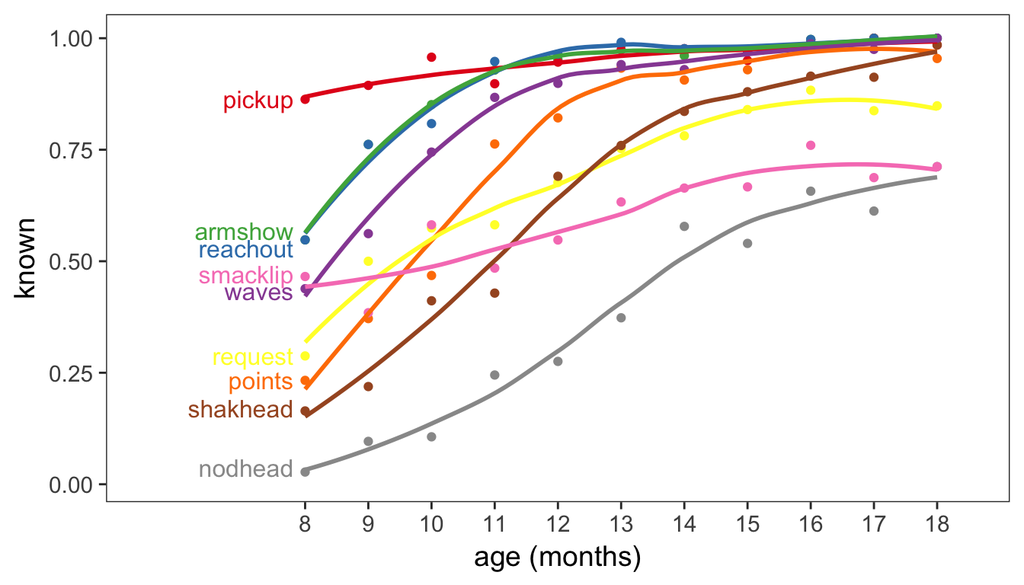

```r
first_gestures_binary <- first_gestures_ordered %>%
  filter(value == "not yet") %>%
  mutate(known = 1- n)

ggplot(first_gestures_binary, aes(x = age, y = known, color = definition,
                                  label = definition)) +
  geom_point() +
  geom_smooth(method = "loess", se = FALSE) +
  geom_dl(method = list(dl.trans(x=x -.2), "first.qp", cex=1)) +
  scale_color_brewer(palette = "Set1") +
  scale_x_continuous(name = "age (months)", limits = c(5.5, 18.5),
                    breaks = seq(8, 18))
```

These look pretty reasonable to me, and a lot more stable. Also smacklip doesn’t seem to have much of any kind of trajectory, which makes me think that parents don’t know what do with it. For comparison, let’s try the other gesture categories.

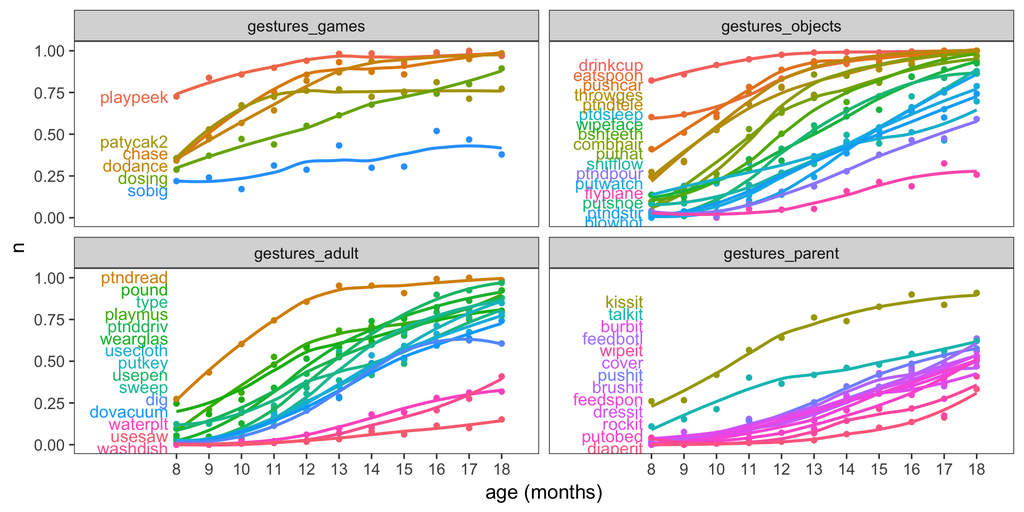

```r
# Get the First Gestures
other <- gesture_data %>%
  filter(type != "gestures_first") %>%
  filter(!is.na(value)) %>%
  mutate(value = parse_factor(value, c("no", "yes"))) %>%
  group_by(age, type, definition, value) %>%
  summarise(n = n()) %>%
  mutate(n = n/sum(n)) %>%
  complete(age, nesting(type, definition), value, fill = list(n = 0)) %>%
  filter(value == "yes")

# Order by approxiamate acquistion order to make plotting nicer
other_type_order <- other %>%
  group_by(type, definition) %>%
  summarise(n = mean(n)) %>%
  summarise(n = mean(n)) %>%
  arrange(desc(n))

other_indiv_order <- other %>%
  ungroup() %>%
  mutate(type = parse_factor(type, other_type_order$type)) %>%
  group_by(type, definition) %>%
  summarise(n = mean(n)) %>%
  arrange(desc(n))

other_gestures_ordered <- other %>%
  ungroup() %>%
  mutate(type = parse_factor(type, other_type_order$type)) %>%
  mutate(definition = parse_factor(definition, other_indiv_order$definition))

ggplot(other_gestures_ordered, aes(x = age, y = n, color = definition,
                                  label = definition)) +
  facet_wrap(~ type) +
  geom_point() +
  geom_smooth(method = "loess", se = FALSE) +
  geom_dl(method = list(dl.trans(x=x -.2), "first.qp", cex=1)) +
  #scale_color_brewer(palette = "Set1") +
  scale_x_continuous(name = "age (months)", limits = c(5.5, 18.5),
                    breaks = seq(8, 18))
```

Interesting, ok most of these look like they have some signal (with the exception maybe of sobig). Also some of them don’t look terribly different from the First Gestures.

Let’s try looking at correlations with vocabulary size

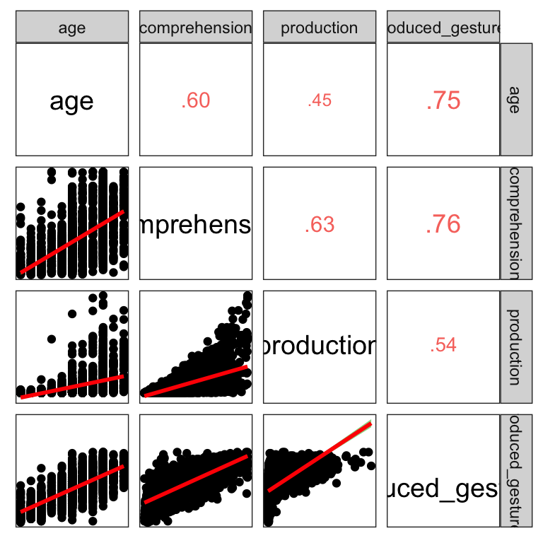

```r
cor_data <- gesture_data %>%
  filter(!is.na(value), !value %in% c("no", "not yet")) %>%
  group_by(age, comprehension, production, data_id) %>%
  summarise(produced_gestures = n())

cols <- c("comprehension", "production", "produced_gestures")

cor_data %>% select_(.dots = cols) %>%
  ggcorplot()
```

```r
num_gestures <- length(unique(gesture_data$definition))

age_cor <- glmer(cbind(produced_gestures, num_gestures - produced_gestures)
                 ~ scale(age) + (1|data_id),
                 family = "binomial", data = cor_data)


age_production_cor <- glmer(cbind(produced_gestures, num_gestures - produced_gestures)
                 ~ scale(age) + scale(production) + (1|data_id),
                 family = "binomial", data = cor_data)

summary(age_production_cor)
```

```
## Generalized linear mixed model fit by maximum likelihood (Laplace
##   Approximation) [glmerMod]
##  Family: binomial  ( logit )
## Formula: cbind(produced_gestures, num_gestures - produced_gestures) ~
##     scale(age) + scale(production) + (1 | data_id)
##    Data: cor_data
##
##      AIC      BIC   logLik deviance df.resid
##  16997.2  17020.4  -8494.6  16989.2     2430
##
## Scaled residuals:
##      Min       1Q   Median       3Q      Max
## -2.39115 -0.30211 -0.01556  0.27692  2.68485
##
## Random effects:
##  Groups  Name        Variance Std.Dev.
##  data_id (Intercept) 0.2875   0.5362
## Number of obs: 2434, groups:  data_id, 2434
##
## Fixed effects:
##                   Estimate Std. Error z value Pr(>|z|)
## (Intercept)        0.14989    0.01227   12.22   <2e-16 ***
## scale(age)         0.59606    0.01402   42.53   <2e-16 ***
## scale(production)  0.26313    0.01448   18.17   <2e-16 ***
## ---
## Signif. codes:  0 '***' 0.001 '**' 0.01 '*' 0.05 '.' 0.1 ' ' 1
##
## Correlation of Fixed Effects:
##             (Intr) scl(g)
## scale(age)  -0.014
## scl(prdctn)  0.029 -0.450
```

```r
age_comprehension_cor <- glmer(cbind(produced_gestures, num_gestures - produced_gestures)
                 ~ scale(age) + scale(comprehension) + (1|data_id),
                 family = "binomial", data = cor_data)

summary(age_comprehension_cor)
```

```
## Generalized linear mixed model fit by maximum likelihood (Laplace
##   Approximation) [glmerMod]
##  Family: binomial  ( logit )
## Formula: cbind(produced_gestures, num_gestures - produced_gestures) ~
##     scale(age) + scale(comprehension) + (1 | data_id)
##    Data: cor_data
##
##      AIC      BIC   logLik deviance df.resid
##  16336.8  16360.0  -8164.4  16328.8     2430
##
## Scaled residuals:
##      Min       1Q   Median       3Q      Max
## -2.44108 -0.34002 -0.01794  0.31467  3.04034
##
## Random effects:
##  Groups  Name        Variance Std.Dev.
##  data_id (Intercept) 0.1983   0.4453
## Number of obs: 2434, groups:  data_id, 2434
##
## Fixed effects:
##                      Estimate Std. Error z value Pr(>|z|)
## (Intercept)           0.14965    0.01065   14.05   <2e-16 ***
## scale(age)            0.43318    0.01341   32.30   <2e-16 ***
## scale(comprehension)  0.46264    0.01346   34.37   <2e-16 ***
## ---
## Signif. codes:  0 '***' 0.001 '**' 0.01 '*' 0.05 '.' 0.1 ' ' 1
##
## Correlation of Fixed Effects:
##             (Intr) scl(g)
## scale(age)  -0.015
## scl(cmprhn)  0.024 -0.580
```

```r
age_both_cor <- glmer(cbind(produced_gestures, num_gestures - produced_gestures)
                 ~ scale(age) + scale(comprehension) + scale(production) +  (1|data_id),
                 family = "binomial", data = cor_data)

summary(age_both_cor)
```

```
## Generalized linear mixed model fit by maximum likelihood (Laplace
##   Approximation) [glmerMod]
##  Family: binomial  ( logit )
## Formula: cbind(produced_gestures, num_gestures - produced_gestures) ~
##     scale(age) + scale(comprehension) + scale(production) + (1 |
##         data_id)
##    Data: cor_data
##
##      AIC      BIC   logLik deviance df.resid
##    16318    16347    -8154    16308     2429
##
## Scaled residuals:
##      Min       1Q   Median       3Q      Max
## -2.45408 -0.34620 -0.01623  0.31725  3.05044
##
## Random effects:
##  Groups  Name        Variance Std.Dev.
##  data_id (Intercept) 0.196    0.4427
## Number of obs: 2434, groups:  data_id, 2434
##
## Fixed effects:
##                      Estimate Std. Error z value Pr(>|z|)
## (Intercept)           0.15077    0.01061  14.205  < 2e-16 ***
## scale(age)            0.42424    0.01349  31.439  < 2e-16 ***
## scale(comprehension)  0.42833    0.01534  27.914  < 2e-16 ***
## scale(production)     0.06568    0.01439   4.563 5.05e-06 ***
## ---
## Signif. codes:  0 '***' 0.001 '**' 0.01 '*' 0.05 '.' 0.1 ' ' 1
##
## Correlation of Fixed Effects:
##             (Intr) scl(g) scl(c)
## scale(age)  -0.018
## scl(cmprhn)  0.010 -0.432
## scl(prdctn)  0.025 -0.143 -0.485
```

```r
anova(age_production_cor, age_cor)
```

```
## Data: cor_data
## Models:
## age_cor: cbind(produced_gestures, num_gestures - produced_gestures) ~
## age_cor:     scale(age) + (1 | data_id)
## age_production_cor: cbind(produced_gestures, num_gestures - produced_gestures) ~
## age_production_cor:     scale(age) + scale(production) + (1 | data_id)
##                    Df   AIC   BIC  logLik deviance  Chisq Chi Df
## age_cor             3 17311 17328 -8652.6    17305
## age_production_cor  4 16997 17020 -8494.6    16989 315.91      1
##                    Pr(>Chisq)
## age_cor
## age_production_cor  < 2.2e-16 ***
## ---
## Signif. codes:  0 '***' 0.001 '**' 0.01 '*' 0.05 '.' 0.1 ' ' 1
```

```r
anova(age_comprehension_cor, age_cor)
```

```
## Data: cor_data
## Models:
## age_cor: cbind(produced_gestures, num_gestures - produced_gestures) ~
## age_cor:     scale(age) + (1 | data_id)
## age_comprehension_cor: cbind(produced_gestures, num_gestures - produced_gestures) ~
## age_comprehension_cor:     scale(age) + scale(comprehension) + (1 | data_id)
##                       Df   AIC   BIC  logLik deviance  Chisq Chi Df
## age_cor                3 17311 17328 -8652.6    17305
## age_comprehension_cor  4 16337 16360 -8164.4    16329 976.28      1
##                       Pr(>Chisq)
## age_cor
## age_comprehension_cor  < 2.2e-16 ***
## ---
## Signif. codes:  0 '***' 0.001 '**' 0.01 '*' 0.05 '.' 0.1 ' ' 1
```

```r
anova(age_comprehension_cor, age_both_cor)
```

```
## Data: cor_data
## Models:
## age_comprehension_cor: cbind(produced_gestures, num_gestures - produced_gestures) ~
## age_comprehension_cor:     scale(age) + scale(comprehension) + (1 | data_id)
## age_both_cor: cbind(produced_gestures, num_gestures - produced_gestures) ~
## age_both_cor:     scale(age) + scale(comprehension) + scale(production) + (1 |
## age_both_cor:         data_id)
##                       Df   AIC   BIC  logLik deviance  Chisq Chi Df
## age_comprehension_cor  4 16337 16360 -8164.4    16329
## age_both_cor           5 16318 16347 -8154.0    16308 20.789      1
##                       Pr(>Chisq)
## age_comprehension_cor
## age_both_cor           5.127e-06 ***
## ---
## Signif. codes:  0 '***' 0.001 '**' 0.01 '*' 0.05 '.' 0.1 ' ' 1
```

```r
age_interaction_cor <- glmer(cbind(produced_gestures, num_gestures - produced_gestures)
                             ~ scale(age) * scale(comprehension) + scale(age) *
                               scale(production) + (1|data_id),
                             control = glmerControl(optimizer = "bobyqa"),
                 family = "binomial", data = cor_data)

anova(age_comprehension_cor, age_interaction_cor)
```

```
## Data: cor_data
## Models:
## age_comprehension_cor: cbind(produced_gestures, num_gestures - produced_gestures) ~
## age_comprehension_cor:     scale(age) + scale(comprehension) + (1 | data_id)
## age_interaction_cor: cbind(produced_gestures, num_gestures - produced_gestures) ~
## age_interaction_cor:     scale(age) * scale(comprehension) + scale(age) * scale(production) +
## age_interaction_cor:         (1 | data_id)
##                       Df   AIC   BIC  logLik deviance Chisq Chi Df
## age_comprehension_cor  4 16337 16360 -8164.4    16329
## age_interaction_cor    7 16250 16291 -8118.3    16236 92.32      3
##                       Pr(>Chisq)
## age_comprehension_cor
## age_interaction_cor    < 2.2e-16 ***
## ---
## Signif. codes:  0 '***' 0.001 '**' 0.01 '*' 0.05 '.' 0.1 ' ' 1
```

```r
summary(age_interaction_cor)
```

```
## Generalized linear mixed model fit by maximum likelihood (Laplace
##   Approximation) [glmerMod]
##  Family: binomial  ( logit )
## Formula: cbind(produced_gestures, num_gestures - produced_gestures) ~
##     scale(age) * scale(comprehension) + scale(age) * scale(production) +
##         (1 | data_id)
##    Data: cor_data
## Control: glmerControl(optimizer = "bobyqa")
##
##      AIC      BIC   logLik deviance df.resid
##  16250.5  16291.1  -8118.3  16236.5     2427
##
## Scaled residuals:
##      Min       1Q   Median       3Q      Max
## -2.54909 -0.35685 -0.02043  0.31887  3.07812
##
## Random effects:
##  Groups  Name        Variance Std.Dev.
##  data_id (Intercept) 0.188    0.4336
## Number of obs: 2434, groups:  data_id, 2434
##
## Fixed effects:
##                                 Estimate Std. Error z value Pr(>|z|)
## (Intercept)                      0.22164    0.01349  16.425  < 2e-16 ***
## scale(age)                       0.36969    0.01494  24.752  < 2e-16 ***
## scale(comprehension)             0.42651    0.01576  27.062  < 2e-16 ***
## scale(production)                0.15817    0.02355   6.716 1.87e-11 ***
## scale(age):scale(comprehension) -0.06899    0.01547  -4.461 8.17e-06 ***
## scale(age):scale(production)    -0.07262    0.02258  -3.217   0.0013 **
## ---
## Signif. codes:  0 '***' 0.001 '**' 0.01 '*' 0.05 '.' 0.1 ' ' 1
##
## Correlation of Fixed Effects:
##               (Intr) scl(g) scl(c) scl(p) scl(g):scl(c)
## scale(age)    -0.298
## scl(cmprhn)   -0.035 -0.320
## scl(prdctn)    0.384 -0.378 -0.469
## scl(g):scl(c) -0.213  0.087 -0.238  0.311
## scl(g):scl(p) -0.354  0.306  0.267 -0.777 -0.592
```

Ok so all of the things that are positively correlated contain some signal in predicting each-other over and above age. It also looks like there is some non-linearity in the correlation, because the age * comprehension/production correlations are negative. Presumably this is some kind of ceiling effect where the gestures in general are producted before the words? Let’s check that next.